# Satellite Image Time Series Classification with Pixel-Set Encoders and Temporal Self-Attention

#### V. Sainte Fare Garnot1, L. Landrieu1, S. Giordano1, N. Chehata1,2

#### 2019

##### Implementation attempted by Vaishnavi Shankar Devadig, 2023

### Background

The paper considers agricultural measures taken in the European Union and aims at improving them with machine learning. With the increasing availability of high-quality satellite data from both public and private sources, there are applications like crop type classification, that are crucial for agricultural and environmental policies with billion-euro subsidies in the EU.

Automation is critical, aided by the Sentinel-2 satellite's high resolution and revisit time, perfect for capturing crop development. Additionally, farmers' yearly declarations provide massive labeled data for training algorithms.

While traditional methods like Random Forest and Support Vector Machine have been used, recent advancement in deep learning, particularly hybrid convolutional-recurrent neural networks, offer improved performance. However, the paper argues that these hybrid architectures have limitations in adapting to specific characteristics of this problem, and this is explored further in this paper.

### Concern

This paper tackles the challenge of crop type classification using satellite imagery. While traditional methods utilize texture-heavy features, the authors propose a novel approach considering:

Spatial Encoding: They treat agricultural parcels as unordered sets of pixels, using techniques from 3D point cloud processing to extract meaningful statistics from the spectral distribution within each parcel. This method adapts better to varying parcel sizes compared to conventional CNNs.

Temporal Encoding: Inspired by advancements in Natural Language Processing, and the Transformer architecture introduced by Vaswani, they employ an attention-based approach to analyze the temporal dimension of satellite data (seasonal changes). This offers improved parallelism, crucial for processing massive datasets covering large areas.

### Data

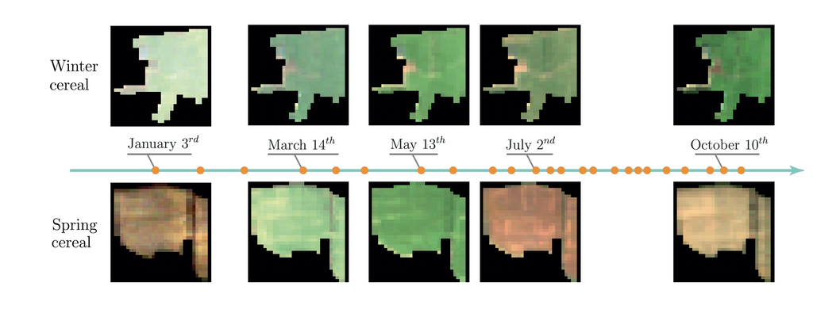

Sentinel-2 time series for two parcels of the Winter cereal and Spring cereal classes (RGB bands, 10m per pixel).

Dots on the x-axis mark the acquisition dates of the parcels. They highlight the crucial role of temporal changes in classifying the parcels.

### Model Architecture

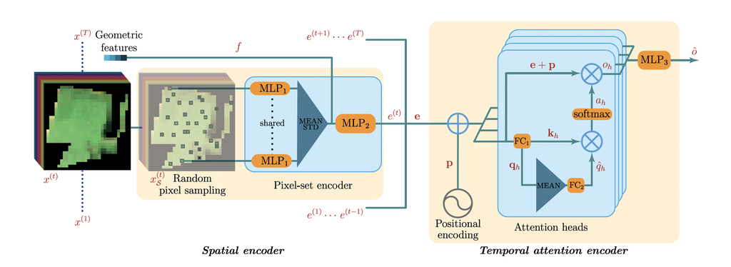

The model architecture consists of a Pixel Set Encoder and a Temporal Attention Encoder:

- **Pixel-Set Encoder:**

  These process satellite image pixels by encoding them into a feature space. Unlike traditional CNNs that require structured grid data, PSEs can handle irregularly sampled pixels, making them well-suited for satellite imagery with varying resolutions and coverage.
- **Temporal Attention Encoder:**

  This component is used to capture temporal relationships across different time steps in the satellite image time series. It allows the model to weigh the importance of each time step differently, focusing on more relevant ones for classification tasks.

### Flow

**Spatial Encoder (Pixel-Set Encoder - PSE):** It replaces traditional CNNs, which may not be suitable for medium-resolution satellite images due to texture capture challenges. The PSE is inspired by the point-set encoder PointNet and the Deep- Set architecture commonly used for 3D point cloud processing, it works by sampling a fixed number of pixels within each parcel and then processes each pixel through a shared multilayer perceptron (MLP1). The output is pooled to get statistical descriptors, which are invariant to the permutation of pixels. This is further processed by another perceptron (MLP2) to produce the parcel's spatio-spectral embedding at a certain time t.

**Temporal Attention Encoder:** It is inspired by the Transformer architecture, leveraging self-attention mechanisms to process sequential data.

- Multi-Head Self-Attention- The TAE employs a multi-head self-attention mechanism that allows the model to focus on different parts of the input sequence simultaneously. For each attention head h, the model computes a set of keys $k_{h}$$^{(t)}$, queries $q_{h}$$^{(t)}$, and values $v_{h}$$^{(t)}$ or each time step t in the input sequence.

- Positional Encoding- To capture the temporal order of observations, positional encoding $p^{(t)}$ is added to the input features. This encoding is calculated using a sinusoidal function of the time step t, ensuring that the model can distinguish the position of each time step in the sequence.

- Attention Weights- For each head, the model computes attention weights $a_{h}$ using the softmax function applied to the dot product of the query and all keys, scaled by the square root of the dimensionality of the keys $\sqrt{d_{k}}$. This attention mechanism enables the model to weight the importance of each value based on the query and its relevance to the keys.

- Output Sequence- The weighted sum of the values $v_{h}$$^{(t)}$, multiplied by the attention weights $a_{h}$ produces an output sequence $o_{h}$ for each head. These sequences are then concatenated and passed through a feed-forward neural network (MLP3) to obtain a final spatio-temporal representation $\hat{o}$.

- Sequence-to-Embedding Attention- The TAE also introduces a sequence-to-embedding attention mechanism where a master query $\hat{q_h}$ is generated as a temporal average of all queries across the time steps. This master query is used to compute a single attention mask that is applied to the entire sequence, producing a weighted representation that captures the most relevant information across all time steps.

In summary, the TAE part of the model captures complex temporal dependencies by assigning varying levels of importance to different observations in the time series, which is particularly useful for satellite image classification tasks where certain time steps may be more informative than others.

**Spatio-Temporal Encoder:** This combines the spatial and temporal encoders to embed the input images of the time series in parallel. The sequence of embeddings is processed by the temporal encoder, and the final embedding is passed through another MLP (MLP4) to generate class logits for classification.

### Note

Considering, I did not have sufficient compute for training on the entire dataset, I have used the toy version of the Sentinel-2 time series dataset (80:20 split).

Thus, the results are not accurate as expected, and there are very few classes of crops in comparison to the original dataset.

### Implementation

```python
import torch
import torch.utils.data as data
import torchnet as tnt
import numpy as np
from sklearn.model_selection import KFold
from sklearn.metrics import confusion_matrix
import os
import json
import pickle as pkl
import pprint

#Imported other files on PixelSetEncoder, Temporal Self Attention, metrics.
```

### Training

```python
if __name__ == '__main__':
    config = {
        'dataset_folder': '/content/drive/MyDrive/S2-2017-T31TFM-PixelSet-TOY/DATA_train',
        'res_dir': './results',
        'num_workers': 8,
        'rdm_seed': 1,
        'device': 'cuda',
        'display_step': 50,
        'preload': False,
        'kfold': 5,
        'epochs': 100,
        'batch_size': 128,
        'lr': 0.001,
        'gamma': 1,
        'npixel': 64,
        'input_dim': 10,
        'mlp1': [10, 32, 64],
        'pooling': 'mean_std',
        'mlp2': [132, 128],
        'geomfeat': 1,
        'n_head': 4,
        'd_k': 32,
        'mlp3': [512, 128, 128],
        'T': 1000,
        'positions': 'bespoke',
        'lms': None,
        'dropout': 0.2,
        'num_classes': 20,
        'mlp4': [128, 64, 32, 20],
    }
```

##### Output

```python
{'T': 1000,
 'batch_size': 128,
 'd_k': 32,
 'dataset_folder': '/content/drive/MyDrive/S2-2017-T31TFM-PixelSet-TOY/DATA_train',
 'device': 'cuda',
 'display_step': 50,
 'dropout': 0.2,
 'epochs': 100,
 'gamma': 1,
 'geomfeat': 1,
 'input_dim': 10,
 'kfold': 5,
 'lms': None,
 'lr': 0.001,
 'mlp1': [10, 32, 64],
 'mlp2': [132, 128],
 'mlp3': [512, 128, 128],
 'mlp4': [128, 64, 32, 20],
 'n_head': 4,
 'npixel': 64,
 'num_classes': 20,
 'num_workers': 8,
 'pooling': 'mean_std',
 'positions': 'bespoke',
 'preload': False,
 'rdm_seed': 1,
 'res_dir': './results'}
/usr/local/lib/python3.10/dist-packages/torch/utils/data/dataloader.py:557: UserWarning: This DataLoader will create 8 worker processes in total. Our suggested max number of worker in current system is 2, which is smaller than what this DataLoader is going to create. Please be aware that excessive worker creation might get DataLoader running slow or even freeze, lower the worker number to avoid potential slowness/freeze if necessary.
  warnings.warn(_create_warning_msg(
Starting Fold 1
Train 2, Val 1, Test 1
TOTAL TRAINABLE PARAMETERS : 164116
RATIOS: Spatial  12.1% , Temporal  81.0% , Classifier   6.8%
None
EPOCH 1/100
/usr/local/lib/python3.10/dist-packages/torch/utils/data/dataloader.py:557: UserWarning: This DataLoader will create 8 worker processes in total. Our suggested max number of worker in current system is 2, which is smaller than what this DataLoader is going to create. Please be aware that excessive worker creation might get DataLoader running slow or even freeze, lower the worker number to avoid potential slowness/freeze if necessary.
  warnings.warn(_create_warning_msg(
Validation . . .
Loss 4.0083,  Acc 0.00,  IoU 0.0000
EPOCH 2/100
Validation . . .
Loss 4.3802,  Acc 0.00,  IoU 0.0000
EPOCH 3/100
Validation . . .
Loss 4.7302,  Acc 0.00,  IoU 0.0000
EPOCH 4/100
Validation . . .
Loss 4.8239,  Acc 0.00,  IoU 0.0000
EPOCH 5/100
Validation . . .
Loss 4.8316,  Acc 0.00,  IoU 0.0000
EPOCH 6/100
Validation . . .
Loss 4.7544,  Acc 0.00,  IoU 0.0000
EPOCH 7/100
Validation . . .
Loss 4.5592,  Acc 0.00,  IoU 0.0000
EPOCH 8/100
Validation . . .
Loss 4.2719,  Acc 0.00,  IoU 0.0000
EPOCH 9/100
Validation . . .
Loss 3.9720,  Acc 0.00,  IoU 0.0000
EPOCH 10/100
Validation . . .
Loss 3.6088,  Acc 1.23,  IoU 0.0139
EPOCH 11/100
Validation . . .
Loss 3.2415,  Acc 6.17,  IoU 0.0182
EPOCH 12/100
Validation . . .
Loss 2.8651,  Acc 14.81,  IoU 0.0545
EPOCH 13/100
Validation . . .
Loss 2.4338,  Acc 20.99,  IoU 0.0581
EPOCH 14/100
Validation . . .
Loss 2.0466,  Acc 33.33,  IoU 0.0786
EPOCH 15/100
Validation . . .
Loss 1.7879,  Acc 48.15,  IoU 0.1303
EPOCH 16/100
Validation . . .
Loss 1.5959,  Acc 56.79,  IoU 0.1648
EPOCH 17/100
Validation . . .
Loss 1.4743,  Acc 62.96,  IoU 0.1796
EPOCH 18/100
Validation . . .
Loss 1.3906,  Acc 66.67,  IoU 0.1806
EPOCH 19/100
Validation . . .
Loss 1.3394,  Acc 66.67,  IoU 0.1986
EPOCH 20/100
Validation . . .
Loss 1.2917,  Acc 67.90,  IoU 0.2005
EPOCH 21/100
Validation . . .
Loss 1.2392,  Acc 67.90,  IoU 0.2005
EPOCH 22/100
Validation . . .
Loss 1.2249,  Acc 67.90,  IoU 0.2005
EPOCH 23/100
Validation . . .
Loss 1.1652,  Acc 72.84,  IoU 0.2131
EPOCH 24/100
Validation . . .
Loss 1.1346,  Acc 75.31,  IoU 0.2217
EPOCH 25/100
Validation . . .
Loss 1.0984,  Acc 74.07,  IoU 0.2119
EPOCH 26/100
Validation . . .
Loss 1.0664,  Acc 76.54,  IoU 0.2461
EPOCH 27/100
Validation . . .
Loss 0.9953,  Acc 76.54,  IoU 0.2461
EPOCH 28/100
Validation . . .
Loss 0.9703,  Acc 79.01,  IoU 0.3762
EPOCH 29/100
Validation . . .
Loss 0.9437,  Acc 79.01,  IoU 0.3622
EPOCH 30/100
Validation . . .
Loss 0.9315,  Acc 79.01,  IoU 0.3728
EPOCH 31/100
Validation . . .
Loss 0.9107,  Acc 79.01,  IoU 0.2739
EPOCH 32/100
Validation . . .
Loss 0.9266,  Acc 79.01,  IoU 0.3705
EPOCH 33/100
Validation . . .
Loss 0.9373,  Acc 77.78,  IoU 0.4077
EPOCH 34/100
Validation . . .
Loss 0.8908,  Acc 79.01,  IoU 0.2899
EPOCH 35/100
Validation . . .
Loss 0.8987,  Acc 79.01,  IoU 0.2899
EPOCH 36/100
Validation . . .
Loss 0.8965,  Acc 80.25,  IoU 0.3023
EPOCH 37/100
Validation . . .
Loss 0.8948,  Acc 80.25,  IoU 0.2937
EPOCH 38/100
Validation . . .
Loss 0.8501,  Acc 80.25,  IoU 0.3023
EPOCH 39/100
Validation . . .
Loss 0.8308,  Acc 80.25,  IoU 0.2925
EPOCH 40/100
Validation . . .
Loss 0.7996,  Acc 82.72,  IoU 0.3598
EPOCH 41/100
Validation . . .
Loss 0.8025,  Acc 81.48,  IoU 0.3578
EPOCH 42/100
Validation . . .
Loss 0.7963,  Acc 81.48,  IoU 0.3606
EPOCH 43/100
Validation . . .
Loss 0.7707,  Acc 81.48,  IoU 0.3606
EPOCH 44/100
Validation . . .
Loss 0.7712,  Acc 82.72,  IoU 0.3472
EPOCH 45/100
Validation . . .
Loss 0.8028,  Acc 81.48,  IoU 0.3566
EPOCH 46/100
Validation . . .
Loss 0.8089,  Acc 81.48,  IoU 0.3946
EPOCH 47/100
Validation . . .
Loss 0.7771,  Acc 81.48,  IoU 0.4515
EPOCH 48/100
Validation . . .
Loss 0.8032,  Acc 81.48,  IoU 0.3946
EPOCH 49/100
Validation . . .
Loss 0.7964,  Acc 81.48,  IoU 0.4014
EPOCH 50/100
Validation . . .
Loss 0.7003,  Acc 83.95,  IoU 0.4778
EPOCH 51/100
Validation . . .
Loss 0.6803,  Acc 85.19,  IoU 0.4562
EPOCH 52/100
Validation . . .
Loss 0.6508,  Acc 83.95,  IoU 0.4161
EPOCH 53/100
Validation . . .
Loss 0.6840,  Acc 83.95,  IoU 0.4036
EPOCH 54/100
Validation . . .
Loss 0.6569,  Acc 85.19,  IoU 0.4562
EPOCH 55/100
Validation . . .
Loss 0.6841,  Acc 85.19,  IoU 0.4562
EPOCH 56/100
Validation . . .
Loss 0.6792,  Acc 83.95,  IoU 0.4036
EPOCH 57/100
Validation . . .
Loss 0.6885,  Acc 83.95,  IoU 0.3989
EPOCH 58/100
Validation . . .
Loss 0.7123,  Acc 83.95,  IoU 0.4488
EPOCH 59/100
Validation . . .
Loss 0.6848,  Acc 83.95,  IoU 0.4421
EPOCH 60/100
Validation . . .
Loss 0.6750,  Acc 83.95,  IoU 0.4507
EPOCH 61/100
Validation . . .
Loss 0.7027,  Acc 83.95,  IoU 0.4361
EPOCH 62/100
Validation . . .
Loss 0.6754,  Acc 85.19,  IoU 0.4450
EPOCH 63/100
Validation . . .
Loss 0.6719,  Acc 83.95,  IoU 0.4428
EPOCH 64/100
Validation . . .
Loss 0.6925,  Acc 83.95,  IoU 0.4920
EPOCH 65/100
Validation . . .
Loss 0.6832,  Acc 83.95,  IoU 0.4361
EPOCH 66/100
Validation . . .
Loss 0.6682,  Acc 82.72,  IoU 0.4263
EPOCH 67/100
Validation . . .
Loss 0.6344,  Acc 85.19,  IoU 0.4450
EPOCH 68/100
Validation . . .
Loss 0.6151,  Acc 85.19,  IoU 0.4510
EPOCH 69/100
Validation . . .
Loss 0.6146,  Acc 86.42,  IoU 0.5239
EPOCH 70/100
Validation . . .
Loss 0.6149,  Acc 85.19,  IoU 0.5132
EPOCH 71/100
Validation . . .
Loss 0.6183,  Acc 85.19,  IoU 0.5132
EPOCH 72/100
Validation . . .
Loss 0.6198,  Acc 85.19,  IoU 0.5132
EPOCH 73/100
Validation . . .
Loss 0.5985,  Acc 85.19,  IoU 0.5192
EPOCH 74/100
Validation . . .
Loss 0.6191,  Acc 85.19,  IoU 0.5244
EPOCH 75/100
Validation . . .
Loss 0.6163,  Acc 86.42,  IoU 0.6863
EPOCH 76/100
Validation . . .
Loss 0.6063,  Acc 85.19,  IoU 0.5296
EPOCH 77/100
Validation . . .
Loss 0.5936,  Acc 86.42,  IoU 0.5442
EPOCH 78/100
Validation . . .
Loss 0.6138,  Acc 85.19,  IoU 0.6682
EPOCH 79/100
Validation . . .
Loss 0.5857,  Acc 86.42,  IoU 0.5510
EPOCH 80/100
Validation . . .
Loss 0.5673,  Acc 86.42,  IoU 0.6171
EPOCH 81/100
Validation . . .
Loss 0.6030,  Acc 86.42,  IoU 0.6159
EPOCH 82/100
Validation . . .
Loss 0.6214,  Acc 85.19,  IoU 0.5318
EPOCH 83/100
Validation . . .
Loss 0.6227,  Acc 85.19,  IoU 0.6007
EPOCH 84/100
Validation . . .
Loss 0.5708,  Acc 85.19,  IoU 0.5318
EPOCH 85/100
Validation . . .
Loss 0.5730,  Acc 85.19,  IoU 0.5230
EPOCH 86/100
Validation . . .
Loss 0.5682,  Acc 85.19,  IoU 0.5126
EPOCH 87/100
Validation . . .
Loss 0.6234,  Acc 83.95,  IoU 0.5189
EPOCH 88/100
Validation . . .
Loss 0.6226,  Acc 85.19,  IoU 0.6007
EPOCH 89/100
Validation . . .
Loss 0.5528,  Acc 86.42,  IoU 0.5635
EPOCH 90/100
Validation . . .
Loss 0.5929,  Acc 85.19,  IoU 0.5360
EPOCH 91/100
Validation . . .
Loss 0.5709,  Acc 82.72,  IoU 0.5039
EPOCH 92/100
Validation . . .
Loss 0.6254,  Acc 83.95,  IoU 0.5827
EPOCH 93/100
Validation . . .
Loss 0.5539,  Acc 85.19,  IoU 0.6542
EPOCH 94/100
Validation . . .
Loss 0.5771,  Acc 85.19,  IoU 0.5281
EPOCH 95/100
Validation . . .
Loss 0.6162,  Acc 83.95,  IoU 0.5100
EPOCH 96/100
Validation . . .
Loss 0.5933,  Acc 86.42,  IoU 0.6055
EPOCH 97/100
Validation . . .
Loss 0.5978,  Acc 82.72,  IoU 0.4895
EPOCH 98/100
Validation . . .
Loss 0.6028,  Acc 85.19,  IoU 0.5126
EPOCH 99/100
Validation . . .
Loss 0.5923,  Acc 87.65,  IoU 0.6080
EPOCH 100/100
Validation . . .
Loss 0.5794,  Acc 86.42,  IoU 0.4726
Testing best epoch . . .
Loss 0.8451,  Acc 80.25,  IoU 0.2151
Starting Fold 2
Train 2, Val 1, Test 1
TOTAL TRAINABLE PARAMETERS : 164116
RATIOS: Spatial  12.1% , Temporal  81.0% , Classifier   6.8%
None
EPOCH 1/100
/usr/local/lib/python3.10/dist-packages/torch/utils/data/dataloader.py:557: UserWarning: This DataLoader will create 8 worker processes in total. Our suggested max number of worker in current system is 2, which is smaller than what this DataLoader is going to create. Please be aware that excessive worker creation might get DataLoader running slow or even freeze, lower the worker number to avoid potential slowness/freeze if necessary.
  warnings.warn(_create_warning_msg(
Validation . . .
Loss 4.8170,  Acc 0.00,  IoU 0.0000
EPOCH 2/100
Validation . . .
Loss 4.4157,  Acc 0.00,  IoU 0.0000
EPOCH 3/100
Validation . . .
Loss 4.1006,  Acc 0.00,  IoU 0.0000
EPOCH 4/100
Validation . . .
Loss 3.8572,  Acc 0.00,  IoU 0.0000
EPOCH 5/100
Validation . . .
Loss 3.6502,  Acc 0.00,  IoU 0.0000
EPOCH 6/100
Validation . . .
Loss 3.4398,  Acc 0.00,  IoU 0.0000
EPOCH 7/100
Validation . . .
Loss 3.2419,  Acc 0.00,  IoU 0.0000
EPOCH 8/100
Validation . . .
Loss 3.0698,  Acc 1.23,  IoU 0.0017
EPOCH 9/100
Validation . . .
Loss 2.9499,  Acc 2.47,  IoU 0.0216
EPOCH 10/100
Validation . . .
Loss 2.8274,  Acc 2.47,  IoU 0.0182
EPOCH 11/100
Validation . . .
Loss 2.7407,  Acc 2.47,  IoU 0.0181
EPOCH 12/100
Validation . . .
Loss 2.6624,  Acc 2.47,  IoU 0.0175
EPOCH 13/100
Validation . . .
Loss 2.5679,  Acc 2.47,  IoU 0.0156
EPOCH 14/100
Validation . . .
Loss 2.4806,  Acc 2.47,  IoU 0.0141
EPOCH 15/100
Validation . . .
Loss 2.3498,  Acc 4.94,  IoU 0.0330
EPOCH 16/100
Validation . . .
Loss 2.2220,  Acc 4.94,  IoU 0.0391
EPOCH 17/100
Validation . . .
Loss 2.1117,  Acc 4.94,  IoU 0.0349
EPOCH 18/100
Validation . . .
Loss 2.0106,  Acc 9.88,  IoU 0.0546
EPOCH 19/100
Validation . . .
Loss 1.9200,  Acc 14.81,  IoU 0.0679
EPOCH 20/100
Validation . . .
Loss 1.8474,  Acc 16.05,  IoU 0.0880
EPOCH 21/100
Validation . . .
Loss 1.8096,  Acc 19.75,  IoU 0.1416
EPOCH 22/100
Validation . . .
Loss 1.7071,  Acc 22.22,  IoU 0.1416
EPOCH 23/100
Validation . . .
Loss 1.6532,  Acc 23.46,  IoU 0.1716
EPOCH 24/100
Validation . . .
Loss 1.6319,  Acc 23.46,  IoU 0.1568
EPOCH 25/100
Validation . . .
Loss 1.5849,  Acc 34.57,  IoU 0.2255
EPOCH 26/100
Validation . . .
Loss 1.5602,  Acc 35.80,  IoU 0.2278
EPOCH 27/100
Validation . . .
Loss 1.4717,  Acc 49.38,  IoU 0.2660
EPOCH 28/100
Validation . . .
Loss 1.4325,  Acc 53.09,  IoU 0.2597
EPOCH 29/100
Validation . . .
Loss 1.3532,  Acc 60.49,  IoU 0.2966
EPOCH 30/100
Validation . . .
Loss 1.2944,  Acc 69.14,  IoU 0.3408
EPOCH 31/100
Validation . . .
Loss 1.2593,  Acc 66.67,  IoU 0.3223
EPOCH 32/100
Validation . . .
Loss 1.2135,  Acc 71.60,  IoU 0.3327
EPOCH 33/100
Validation . . .
Loss 1.1695,  Acc 75.31,  IoU 0.3677
EPOCH 34/100
Validation . . .
Loss 1.1535,  Acc 79.01,  IoU 0.3634
EPOCH 35/100
Validation . . .
Loss 1.1140,  Acc 79.01,  IoU 0.4286
EPOCH 36/100
Validation . . .
Loss 1.0871,  Acc 81.48,  IoU 0.4104
EPOCH 37/100
Validation . . .
Loss 1.0430,  Acc 83.95,  IoU 0.4211
EPOCH 38/100
Validation . . .
Loss 1.0162,  Acc 83.95,  IoU 0.4469
EPOCH 39/100
Validation . . .
Loss 0.9964,  Acc 85.19,  IoU 0.3984
EPOCH 40/100
Validation . . .
Loss 0.9631,  Acc 85.19,  IoU 0.4519
EPOCH 41/100
Validation . . .
Loss 0.9509,  Acc 83.95,  IoU 0.4220
EPOCH 42/100
Validation . . .
Loss 0.9293,  Acc 83.95,  IoU 0.3692
EPOCH 43/100
Validation . . .
Loss 0.9183,  Acc 82.72,  IoU 0.3925
EPOCH 44/100
Validation . . .
Loss 0.8896,  Acc 82.72,  IoU 0.3925
EPOCH 45/100
Validation . . .
Loss 0.8740,  Acc 82.72,  IoU 0.3925
```

```python
EPOCH 46/100
Validation . . .
Loss 0.8450,  Acc 82.72,  IoU 0.3925
EPOCH 47/100
Validation . . .
Loss 0.8286,  Acc 82.72,  IoU 0.3925
EPOCH 48/100
Validation . . .
Loss 0.8327,  Acc 83.95,  IoU 0.4138
EPOCH 49/100
Validation . . .
Loss 0.8165,  Acc 82.72,  IoU 0.3914
EPOCH 50/100
Validation . . .
Loss 0.7919,  Acc 82.72,  IoU 0.4067
EPOCH 51/100
Validation . . .
Loss 0.7619,  Acc 83.95,  IoU 0.4126
EPOCH 52/100
Validation . . .
Loss 0.7396,  Acc 86.42,  IoU 0.4582
EPOCH 53/100
Validation . . .
Loss 0.7257,  Acc 86.42,  IoU 0.4582
EPOCH 54/100
Validation . . .
Loss 0.7155,  Acc 86.42,  IoU 0.4537
EPOCH 55/100
Validation . . .
Loss 0.6984,  Acc 85.19,  IoU 0.4311
EPOCH 56/100
Validation . . .
Loss 0.6964,  Acc 85.19,  IoU 0.4247
EPOCH 57/100
Validation . . .
Loss 0.6946,  Acc 85.19,  IoU 0.4247
EPOCH 58/100
Validation . . .
Loss 0.6911,  Acc 85.19,  IoU 0.4247
EPOCH 59/100
Validation . . .
Loss 0.6667,  Acc 86.42,  IoU 0.4389
EPOCH 60/100
Validation . . .
Loss 0.6477,  Acc 86.42,  IoU 0.4582
EPOCH 61/100
Validation . . .
Loss 0.6518,  Acc 85.19,  IoU 0.4293
EPOCH 62/100
Validation . . .
Loss 0.6474,  Acc 85.19,  IoU 0.4293
EPOCH 63/100
Validation . . .
Loss 0.6329,  Acc 86.42,  IoU 0.4582
EPOCH 64/100
Validation . . .
Loss 0.6216,  Acc 87.65,  IoU 0.6150
EPOCH 65/100
Validation . . .
Loss 0.6106,  Acc 87.65,  IoU 0.6150
EPOCH 66/100
Validation . . .
Loss 0.6053,  Acc 87.65,  IoU 0.6150
EPOCH 67/100
Validation . . .
Loss 0.6347,  Acc 86.42,  IoU 0.5832
EPOCH 68/100
Validation . . .
Loss 0.6025,  Acc 87.65,  IoU 0.6150
EPOCH 69/100
Validation . . .
Loss 0.6016,  Acc 88.89,  IoU 0.6246
EPOCH 70/100
Validation . . .
Loss 0.5963,  Acc 87.65,  IoU 0.5444
EPOCH 71/100
Validation . . .
Loss 0.5791,  Acc 87.65,  IoU 0.5444
EPOCH 72/100
Validation . . .
Loss 0.5631,  Acc 87.65,  IoU 0.5444
EPOCH 73/100
Validation . . .
Loss 0.5582,  Acc 87.65,  IoU 0.5444
EPOCH 74/100
Validation . . .
Loss 0.5548,  Acc 87.65,  IoU 0.4931
EPOCH 75/100
Validation . . .
Loss 0.5555,  Acc 86.42,  IoU 0.5166
EPOCH 76/100
Validation . . .
Loss 0.5470,  Acc 87.65,  IoU 0.5444
EPOCH 77/100
Validation . . .
Loss 0.5532,  Acc 87.65,  IoU 0.5444
EPOCH 78/100
Validation . . .
Loss 0.5402,  Acc 86.42,  IoU 0.4079
EPOCH 79/100
Validation . . .
Loss 0.5365,  Acc 87.65,  IoU 0.5009
EPOCH 80/100
Validation . . .
Loss 0.5424,  Acc 86.42,  IoU 0.4783
EPOCH 81/100
Validation . . .
Loss 0.5345,  Acc 87.65,  IoU 0.5009
EPOCH 82/100
Validation . . .
Loss 0.5154,  Acc 87.65,  IoU 0.5009
EPOCH 83/100
Validation . . .
Loss 0.5023,  Acc 87.65,  IoU 0.5009
EPOCH 84/100
Validation . . .
Loss 0.5082,  Acc 87.65,  IoU 0.5009
EPOCH 85/100
Validation . . .
Loss 0.5141,  Acc 87.65,  IoU 0.4931
EPOCH 86/100
Validation . . .
Loss 0.4999,  Acc 87.65,  IoU 0.4931
EPOCH 87/100
Validation . . .
Loss 0.4976,  Acc 88.89,  IoU 0.5136
EPOCH 88/100
Validation . . .
Loss 0.4986,  Acc 87.65,  IoU 0.5117
EPOCH 89/100
Validation . . .
Loss 0.4961,  Acc 88.89,  IoU 0.5134
EPOCH 90/100
Validation . . .
Loss 0.5260,  Acc 85.19,  IoU 0.4893
EPOCH 91/100
Validation . . .
Loss 0.5034,  Acc 87.65,  IoU 0.5009
EPOCH 92/100
Validation . . .
Loss 0.5136,  Acc 87.65,  IoU 0.5117
EPOCH 93/100
Validation . . .
Loss 0.5049,  Acc 87.65,  IoU 0.5009
EPOCH 94/100
Validation . . .
Loss 0.5100,  Acc 88.89,  IoU 0.5302
EPOCH 95/100
Validation . . .
Loss 0.5152,  Acc 87.65,  IoU 0.5564
EPOCH 96/100
Validation . . .
Loss 0.5037,  Acc 87.65,  IoU 0.5010
EPOCH 97/100
Validation . . .
Loss 0.4931,  Acc 88.89,  IoU 0.5656
EPOCH 98/100
Validation . . .
Loss 0.5063,  Acc 88.89,  IoU 0.5656
EPOCH 99/100
Validation . . .
Loss 0.5106,  Acc 87.65,  IoU 0.5487
EPOCH 100/100
Validation . . .
Loss 0.4796,  Acc 90.12,  IoU 0.6127
Testing best epoch . . .
Loss 0.6971,  Acc 82.50,  IoU 0.2819
Starting Fold 3
Train 2, Val 1, Test 1
TOTAL TRAINABLE PARAMETERS : 164116
RATIOS: Spatial  12.1% , Temporal  81.0% , Classifier   6.8%
None
EPOCH 1/100
/usr/local/lib/python3.10/dist-packages/torch/utils/data/dataloader.py:557: UserWarning: This DataLoader will create 8 worker processes in total. Our suggested max number of worker in current system is 2, which is smaller than what this DataLoader is going to create. Please be aware that excessive worker creation might get DataLoader running slow or even freeze, lower the worker number to avoid potential slowness/freeze if necessary.
  warnings.warn(_create_warning_msg(
Validation . . .
Loss 2.3313,  Acc 0.00,  IoU 0.0000
EPOCH 2/100
Validation . . .
Loss 2.0990,  Acc 0.00,  IoU 0.0000
EPOCH 3/100
Validation . . .
Loss 1.8982,  Acc 9.88,  IoU 0.0185
EPOCH 4/100
Validation . . .
Loss 1.7495,  Acc 65.43,  IoU 0.0828
EPOCH 5/100
Validation . . .
Loss 1.6343,  Acc 65.43,  IoU 0.0935
EPOCH 6/100
Validation . . .
Loss 1.5445,  Acc 65.43,  IoU 0.0935
EPOCH 7/100
Validation . . .
Loss 1.4618,  Acc 65.43,  IoU 0.0935
EPOCH 8/100
Validation . . .
Loss 1.3713,  Acc 67.90,  IoU 0.1316
EPOCH 9/100
Validation . . .
Loss 1.2832,  Acc 70.37,  IoU 0.1617
EPOCH 10/100
Validation . . .
Loss 1.2169,  Acc 74.07,  IoU 0.2024
EPOCH 11/100
Validation . . .
Loss 1.1774,  Acc 72.84,  IoU 0.1710
EPOCH 12/100
Validation . . .
Loss 1.1482,  Acc 72.84,  IoU 0.1605
EPOCH 13/100
Validation . . .
Loss 1.1305,  Acc 71.60,  IoU 0.1576
EPOCH 14/100
Validation . . .
Loss 1.1070,  Acc 71.60,  IoU 0.1396
EPOCH 15/100
Validation . . .
Loss 1.0591,  Acc 74.07,  IoU 0.1918
EPOCH 16/100
Validation . . .
Loss 1.0211,  Acc 76.54,  IoU 0.2511
EPOCH 17/100
Validation . . .
Loss 0.9695,  Acc 77.78,  IoU 0.2659
EPOCH 18/100
Validation . . .
Loss 0.9180,  Acc 80.25,  IoU 0.2815
EPOCH 19/100
Validation . . .
Loss 0.8615,  Acc 81.48,  IoU 0.2623
EPOCH 20/100
Validation . . .
Loss 0.8191,  Acc 83.95,  IoU 0.3522
EPOCH 21/100
Validation . . .
Loss 0.7493,  Acc 83.95,  IoU 0.3322
EPOCH 22/100
Validation . . .
Loss 0.7374,  Acc 82.72,  IoU 0.3182
EPOCH 23/100
Validation . . .
Loss 0.7156,  Acc 82.72,  IoU 0.3182
EPOCH 24/100
Validation . . .
Loss 0.7076,  Acc 85.19,  IoU 0.5015
EPOCH 25/100
Validation . . .
Loss 0.7034,  Acc 85.19,  IoU 0.5015
EPOCH 26/100
Validation . . .
Loss 0.6919,  Acc 86.42,  IoU 0.5179
EPOCH 27/100
Validation . . .
Loss 0.6912,  Acc 85.19,  IoU 0.5077
EPOCH 28/100
Validation . . .
Loss 0.6842,  Acc 82.72,  IoU 0.3403
EPOCH 29/100
Validation . . .
Loss 0.6493,  Acc 86.42,  IoU 0.5225
EPOCH 30/100
Validation . . .
Loss 0.6328,  Acc 86.42,  IoU 0.3939
EPOCH 31/100
Validation . . .
Loss 0.6223,  Acc 85.19,  IoU 0.3741
EPOCH 32/100
Validation . . .
Loss 0.5830,  Acc 86.42,  IoU 0.4043
EPOCH 33/100
Validation . . .
Loss 0.5999,  Acc 85.19,  IoU 0.3846
EPOCH 34/100
Validation . . .
Loss 0.6060,  Acc 83.95,  IoU 0.3695
EPOCH 35/100
Validation . . .
Loss 0.6004,  Acc 85.19,  IoU 0.5394
EPOCH 36/100
Validation . . .
Loss 0.5865,  Acc 85.19,  IoU 0.4018
EPOCH 37/100
Validation . . .
Loss 0.5833,  Acc 86.42,  IoU 0.5574
EPOCH 38/100
Validation . . .
Loss 0.5787,  Acc 85.19,  IoU 0.5394
EPOCH 39/100
Validation . . .
Loss 0.5815,  Acc 83.95,  IoU 0.3854
EPOCH 40/100
Validation . . .
Loss 0.5688,  Acc 85.19,  IoU 0.4018
EPOCH 41/100
Validation . . .
Loss 0.5616,  Acc 86.42,  IoU 0.5574
EPOCH 42/100
Validation . . .
Loss 0.5578,  Acc 86.42,  IoU 0.4170
EPOCH 43/100
Validation . . .
Loss 0.5765,  Acc 85.19,  IoU 0.4018
EPOCH 44/100
Validation . . .
Loss 0.5453,  Acc 87.65,  IoU 0.5725
EPOCH 45/100
Validation . . .
Loss 0.5599,  Acc 86.42,  IoU 0.4170
EPOCH 46/100
Validation . . .
Loss 0.5611,  Acc 86.42,  IoU 0.4170
EPOCH 47/100
Validation . . .
Loss 0.5522,  Acc 86.42,  IoU 0.4170
EPOCH 48/100
Validation . . .
Loss 0.5505,  Acc 86.42,  IoU 0.5574
EPOCH 49/100
Validation . . .
Loss 0.5427,  Acc 86.42,  IoU 0.5574
EPOCH 50/100
Validation . . .
Loss 0.5541,  Acc 86.42,  IoU 0.5574
EPOCH 51/100
Validation . . .
Loss 0.5567,  Acc 86.42,  IoU 0.5574
EPOCH 52/100
Validation . . .
Loss 0.5459,  Acc 86.42,  IoU 0.5732
EPOCH 53/100
Validation . . .
Loss 0.5483,  Acc 88.89,  IoU 0.5984
EPOCH 54/100
Validation . . .
Loss 0.5721,  Acc 86.42,  IoU 0.4346
EPOCH 55/100
Validation . . .
Loss 0.5763,  Acc 90.12,  IoU 0.7539
EPOCH 56/100
Validation . . .
Loss 0.5663,  Acc 87.65,  IoU 0.5757
EPOCH 57/100
Validation . . .
Loss 0.5577,  Acc 88.89,  IoU 0.7313
EPOCH 58/100
Validation . . .
Loss 0.5563,  Acc 88.89,  IoU 0.7313
EPOCH 59/100
Validation . . .
Loss 0.5430,  Acc 88.89,  IoU 0.7313
EPOCH 60/100
Validation . . .
Loss 0.5471,  Acc 88.89,  IoU 0.7313
EPOCH 61/100
Validation . . .
Loss 0.5425,  Acc 88.89,  IoU 0.7313
EPOCH 62/100
Validation . . .
Loss 0.5212,  Acc 88.89,  IoU 0.7313
EPOCH 63/100
Validation . . .
Loss 0.5270,  Acc 88.89,  IoU 0.7313
EPOCH 64/100
Validation . . .
Loss 0.5279,  Acc 88.89,  IoU 0.5750
EPOCH 65/100
Validation . . .
Loss 0.5230,  Acc 90.12,  IoU 0.7337
EPOCH 66/100
Validation . . .
Loss 0.5159,  Acc 90.12,  IoU 0.7337
EPOCH 67/100
Validation . . .
Loss 0.5222,  Acc 88.89,  IoU 0.7313
EPOCH 68/100
Validation . . .
Loss 0.5239,  Acc 88.89,  IoU 0.7313
EPOCH 69/100
Validation . . .
Loss 0.5358,  Acc 88.89,  IoU 0.7313
EPOCH 70/100
Validation . . .
Loss 0.5420,  Acc 87.65,  IoU 0.6377
EPOCH 71/100
Validation . . .
Loss 0.5506,  Acc 86.42,  IoU 0.6355
EPOCH 72/100
Validation . . .
Loss 0.5524,  Acc 87.65,  IoU 0.6377
EPOCH 73/100
Validation . . .
Loss 0.5563,  Acc 87.65,  IoU 0.6377
EPOCH 74/100
Validation . . .
Loss 0.5591,  Acc 86.42,  IoU 0.6355
EPOCH 75/100
Validation . . .
Loss 0.5641,  Acc 86.42,  IoU 0.6355
EPOCH 76/100
Validation . . .
Loss 0.5444,  Acc 87.65,  IoU 0.6377
EPOCH 77/100
Validation . . .
Loss 0.5524,  Acc 87.65,  IoU 0.5686
EPOCH 78/100
Validation . . .
Loss 0.5465,  Acc 87.65,  IoU 0.5686
EPOCH 79/100
Validation . . .
Loss 0.5612,  Acc 87.65,  IoU 0.5686
EPOCH 80/100
Validation . . .
Loss 0.5673,  Acc 86.42,  IoU 0.5666
EPOCH 81/100
Validation . . .
Loss 0.5609,  Acc 87.65,  IoU 0.5771
EPOCH 82/100
Validation . . .
Loss 0.5429,  Acc 87.65,  IoU 0.5771
EPOCH 83/100
Validation . . .
Loss 0.5282,  Acc 88.89,  IoU 0.6418
EPOCH 84/100
Validation . . .
Loss 0.5249,  Acc 88.89,  IoU 0.6418
EPOCH 85/100
Validation . . .
Loss 0.4967,  Acc 88.89,  IoU 0.6418
EPOCH 86/100
Validation . . .
Loss 0.5131,  Acc 87.65,  IoU 0.6377
EPOCH 87/100
Validation . . .
Loss 0.5162,  Acc 87.65,  IoU 0.7288
EPOCH 88/100
Validation . . .
Loss 0.5208,  Acc 88.89,  IoU 0.7313
EPOCH 89/100
Validation . . .
Loss 0.5352,  Acc 86.42,  IoU 0.6355
EPOCH 90/100
Validation . . .
Loss 0.5289,  Acc 87.65,  IoU 0.7288
EPOCH 91/100
Validation . . .
Loss 0.5244,  Acc 86.42,  IoU 0.5732
EPOCH 92/100
Validation . . .
Loss 0.5264,  Acc 87.65,  IoU 0.7288
EPOCH 93/100
Validation . . .
Loss 0.5399,  Acc 87.65,  IoU 0.7288
EPOCH 94/100
Validation . . .
Loss 0.5485,  Acc 88.89,  IoU 0.7313
EPOCH 95/100
Validation . . .
Loss 0.5371,  Acc 88.89,  IoU 0.7313
EPOCH 96/100
Validation . . .
Loss 0.5528,  Acc 86.42,  IoU 0.5732
EPOCH 97/100
Validation . . .
Loss 0.5522,  Acc 87.65,  IoU 0.7288
EPOCH 98/100
Validation . . .
Loss 0.5448,  Acc 87.65,  IoU 0.7288
EPOCH 99/100
Validation . . .
Loss 0.5529,  Acc 86.42,  IoU 0.5732
EPOCH 100/100
Validation . . .
Loss 0.5587,  Acc 86.42,  IoU 0.5732
Testing best epoch . . .
Loss 0.5704,  Acc 82.50,  IoU 0.2687
Starting Fold 4
Train 2, Val 1, Test 1
TOTAL TRAINABLE PARAMETERS : 164116
RATIOS: Spatial  12.1% , Temporal  81.0% , Classifier   6.8%
None
EPOCH 1/100
/usr/local/lib/python3.10/dist-packages/torch/utils/data/dataloader.py:557: UserWarning: This DataLoader will create 8 worker processes in total. Our suggested max number of worker in current system is 2, which is smaller than what this DataLoader is going to create. Please be aware that excessive worker creation might get DataLoader running slow or even freeze, lower the worker number to avoid potential slowness/freeze if necessary.
  warnings.warn(_create_warning_msg(
Validation . . .
Loss 2.7132,  Acc 9.88,  IoU 0.0141
EPOCH 2/100
Validation . . .
Loss 2.8119,  Acc 9.88,  IoU 0.0141
EPOCH 3/100
Validation . . .
Loss 2.8820,  Acc 9.88,  IoU 0.0141
EPOCH 4/100
Validation . . .
Loss 2.8983,  Acc 9.88,  IoU 0.0130
EPOCH 5/100
```

```python
Validation . . .
Loss 2.9319,  Acc 9.88,  IoU 0.0143
EPOCH 6/100
Validation . . .
Loss 2.9557,  Acc 8.64,  IoU 0.0123
EPOCH 7/100
Validation . . .
Loss 2.9365,  Acc 8.64,  IoU 0.0138
EPOCH 8/100
Validation . . .
Loss 2.8767,  Acc 11.11,  IoU 0.0252
EPOCH 9/100
Validation . . .
Loss 2.7447,  Acc 9.88,  IoU 0.0194
EPOCH 10/100
Validation . . .
Loss 2.5305,  Acc 11.11,  IoU 0.0213
EPOCH 11/100
Validation . . .
Loss 2.2829,  Acc 17.28,  IoU 0.0268
EPOCH 12/100
Validation . . .
Loss 2.0750,  Acc 28.40,  IoU 0.0436
EPOCH 13/100
Validation . . .
Loss 1.8843,  Acc 43.21,  IoU 0.0923
EPOCH 14/100
Validation . . .
Loss 1.7222,  Acc 53.09,  IoU 0.1294
EPOCH 15/100
Validation . . .
Loss 1.6033,  Acc 53.09,  IoU 0.1112
EPOCH 16/100
Validation . . .
Loss 1.5035,  Acc 56.79,  IoU 0.1198
EPOCH 17/100
Validation . . .
Loss 1.4398,  Acc 60.49,  IoU 0.1203
EPOCH 18/100
Validation . . .
Loss 1.3688,  Acc 62.96,  IoU 0.1231
EPOCH 19/100
Validation . . .
Loss 1.3298,  Acc 67.90,  IoU 0.1700
EPOCH 20/100
Validation . . .
Loss 1.2651,  Acc 70.37,  IoU 0.1862
EPOCH 21/100
Validation . . .
Loss 1.1927,  Acc 72.84,  IoU 0.2152
EPOCH 22/100
Validation . . .
Loss 1.1598,  Acc 74.07,  IoU 0.1926
EPOCH 23/100
Validation . . .
Loss 1.1141,  Acc 75.31,  IoU 0.2358
EPOCH 24/100
Validation . . .
Loss 1.0556,  Acc 75.31,  IoU 0.2583
EPOCH 25/100
Validation . . .
Loss 1.0307,  Acc 75.31,  IoU 0.2399
EPOCH 26/100
Validation . . .
Loss 0.9775,  Acc 76.54,  IoU 0.2357
EPOCH 27/100
Validation . . .
Loss 0.9634,  Acc 75.31,  IoU 0.2091
EPOCH 28/100
Validation . . .
Loss 0.9611,  Acc 76.54,  IoU 0.2290
EPOCH 29/100
Validation . . .
Loss 0.9346,  Acc 75.31,  IoU 0.2177
EPOCH 30/100
Validation . . .
Loss 0.9495,  Acc 74.07,  IoU 0.2095
EPOCH 31/100
Validation . . .
Loss 0.9118,  Acc 76.54,  IoU 0.2208
EPOCH 32/100
Validation . . .
Loss 0.9021,  Acc 75.31,  IoU 0.2204
EPOCH 33/100
Validation . . .
Loss 0.9056,  Acc 79.01,  IoU 0.2767
EPOCH 34/100
Validation . . .
Loss 0.8721,  Acc 77.78,  IoU 0.2730
EPOCH 35/100
Validation . . .
Loss 0.8427,  Acc 81.48,  IoU 0.2828
EPOCH 36/100
Validation . . .
Loss 0.8299,  Acc 79.01,  IoU 0.2831
EPOCH 37/100
Validation . . .
Loss 0.8168,  Acc 81.48,  IoU 0.3012
EPOCH 38/100
Validation . . .
Loss 0.8074,  Acc 82.72,  IoU 0.3014
EPOCH 39/100
Validation . . .
Loss 0.8048,  Acc 81.48,  IoU 0.2667
EPOCH 40/100
Validation . . .
Loss 0.7808,  Acc 81.48,  IoU 0.2785
EPOCH 41/100
Validation . . .
Loss 0.7840,  Acc 80.25,  IoU 0.3021
EPOCH 42/100
Validation . . .
Loss 0.7752,  Acc 80.25,  IoU 0.2547
EPOCH 43/100
Validation . . .
Loss 0.7607,  Acc 82.72,  IoU 0.3269
EPOCH 44/100
Validation . . .
Loss 0.7753,  Acc 81.48,  IoU 0.3044
EPOCH 45/100
Validation . . .
Loss 0.7886,  Acc 80.25,  IoU 0.2669
EPOCH 46/100
Validation . . .
Loss 0.7479,  Acc 81.48,  IoU 0.2785
EPOCH 47/100
Validation . . .
Loss 0.7512,  Acc 81.48,  IoU 0.2782
EPOCH 48/100
Validation . . .
Loss 0.7263,  Acc 82.72,  IoU 0.2959
EPOCH 49/100
Validation . . .
Loss 0.7174,  Acc 81.48,  IoU 0.2785
EPOCH 50/100
Validation . . .
Loss 0.7190,  Acc 81.48,  IoU 0.2869
EPOCH 51/100
Validation . . .
Loss 0.7258,  Acc 81.48,  IoU 0.2873
EPOCH 52/100
Validation . . .
Loss 0.7023,  Acc 80.25,  IoU 0.2762
EPOCH 53/100
Validation . . .
Loss 0.7024,  Acc 82.72,  IoU 0.2875
EPOCH 54/100
Validation . . .
Loss 0.6536,  Acc 82.72,  IoU 0.2818
EPOCH 55/100
Validation . . .
Loss 0.6903,  Acc 82.72,  IoU 0.2875
EPOCH 56/100
Validation . . .
Loss 0.6948,  Acc 82.72,  IoU 0.2875
EPOCH 57/100
Validation . . .
Loss 0.7048,  Acc 83.95,  IoU 0.2934
EPOCH 58/100
Validation . . .
Loss 0.6780,  Acc 82.72,  IoU 0.2910
EPOCH 59/100
Validation . . .
Loss 0.6847,  Acc 82.72,  IoU 0.3215
EPOCH 60/100
Validation . . .
Loss 0.6861,  Acc 82.72,  IoU 0.3215
EPOCH 61/100
Validation . . .
Loss 0.6825,  Acc 81.48,  IoU 0.2817
EPOCH 62/100
Validation . . .
Loss 0.6802,  Acc 81.48,  IoU 0.3252
EPOCH 63/100
Validation . . .
Loss 0.6746,  Acc 79.01,  IoU 0.2762
EPOCH 64/100
Validation . . .
Loss 0.6874,  Acc 80.25,  IoU 0.3129
EPOCH 65/100
Validation . . .
Loss 0.6894,  Acc 81.48,  IoU 0.3178
EPOCH 66/100
Validation . . .
Loss 0.6472,  Acc 81.48,  IoU 0.3035
EPOCH 67/100
Validation . . .
Loss 0.6531,  Acc 81.48,  IoU 0.3245
EPOCH 68/100
Validation . . .
Loss 0.6422,  Acc 81.48,  IoU 0.3275
EPOCH 69/100
Validation . . .
Loss 0.6398,  Acc 83.95,  IoU 0.3304
EPOCH 70/100
Validation . . .
Loss 0.6313,  Acc 85.19,  IoU 0.3523
EPOCH 71/100
Validation . . .
Loss 0.6415,  Acc 83.95,  IoU 0.3289
EPOCH 72/100
Validation . . .
Loss 0.6369,  Acc 83.95,  IoU 0.3483
EPOCH 73/100
Validation . . .
Loss 0.6427,  Acc 83.95,  IoU 0.2898
EPOCH 74/100
Validation . . .
Loss 0.6198,  Acc 85.19,  IoU 0.3255
EPOCH 75/100
Validation . . .
Loss 0.6077,  Acc 83.95,  IoU 0.3080
EPOCH 76/100
Validation . . .
Loss 0.6069,  Acc 83.95,  IoU 0.3406
EPOCH 77/100
Validation . . .
Loss 0.6055,  Acc 85.19,  IoU 0.3222
EPOCH 78/100
Validation . . .
Loss 0.6010,  Acc 86.42,  IoU 0.3646
EPOCH 79/100
Validation . . .
Loss 0.5927,  Acc 86.42,  IoU 0.3729
EPOCH 80/100
Validation . . .
Loss 0.6251,  Acc 82.72,  IoU 0.3247
EPOCH 81/100
Validation . . .
Loss 0.6036,  Acc 86.42,  IoU 0.3729
EPOCH 82/100
Validation . . .
Loss 0.6327,  Acc 82.72,  IoU 0.2973
EPOCH 83/100
Validation . . .
Loss 0.5923,  Acc 85.19,  IoU 0.3849
EPOCH 84/100
Validation . . .
Loss 0.6145,  Acc 82.72,  IoU 0.3012
EPOCH 85/100
Validation . . .
Loss 0.6109,  Acc 83.95,  IoU 0.3428
EPOCH 86/100
Validation . . .
Loss 0.6157,  Acc 82.72,  IoU 0.3291
EPOCH 87/100
Validation . . .
Loss 0.6250,  Acc 83.95,  IoU 0.4139
EPOCH 88/100
Validation . . .
Loss 0.5895,  Acc 85.19,  IoU 0.3211
EPOCH 89/100
Validation . . .
Loss 0.6285,  Acc 81.48,  IoU 0.2901
EPOCH 90/100
Validation . . .
Loss 0.6177,  Acc 83.95,  IoU 0.3409
EPOCH 91/100
Validation . . .
Loss 0.6222,  Acc 82.72,  IoU 0.2973
EPOCH 92/100
Validation . . .
Loss 0.5998,  Acc 83.95,  IoU 0.3268
EPOCH 93/100
Validation . . .
Loss 0.6133,  Acc 85.19,  IoU 0.3387
EPOCH 94/100
Validation . . .
Loss 0.6233,  Acc 83.95,  IoU 0.3047
EPOCH 95/100
Validation . . .
Loss 0.5950,  Acc 86.42,  IoU 0.4103
EPOCH 96/100
Validation . . .
Loss 0.6150,  Acc 85.19,  IoU 0.3504
EPOCH 97/100
Validation . . .
Loss 0.6045,  Acc 85.19,  IoU 0.3477
EPOCH 98/100
Validation . . .
Loss 0.5839,  Acc 83.95,  IoU 0.3268
EPOCH 99/100
Validation . . .
Loss 0.5894,  Acc 85.19,  IoU 0.3387
EPOCH 100/100
Validation . . .
Loss 0.5791,  Acc 85.19,  IoU 0.3849
Testing best epoch . . .
Loss 0.7436,  Acc 82.50,  IoU 0.3769
Starting Fold 5
Train 2, Val 1, Test 1
TOTAL TRAINABLE PARAMETERS : 164116
RATIOS: Spatial  12.1% , Temporal  81.0% , Classifier   6.8%
None
EPOCH 1/100
/usr/local/lib/python3.10/dist-packages/torch/utils/data/dataloader.py:557: UserWarning: This DataLoader will create 8 worker processes in total. Our suggested max number of worker in current system is 2, which is smaller than what this DataLoader is going to create. Please be aware that excessive worker creation might get DataLoader running slow or even freeze, lower the worker number to avoid potential slowness/freeze if necessary.
  warnings.warn(_create_warning_msg(
Validation . . .
Loss 4.3941,  Acc 0.00,  IoU 0.0000
EPOCH 2/100
Validation . . .
Loss 4.2273,  Acc 0.00,  IoU 0.0000
EPOCH 3/100
Validation . . .
Loss 4.1449,  Acc 0.00,  IoU 0.0000
EPOCH 4/100
Validation . . .
Loss 4.0921,  Acc 0.00,  IoU 0.0000
EPOCH 5/100
Validation . . .
Loss 3.9743,  Acc 0.00,  IoU 0.0000
EPOCH 6/100
Validation . . .
Loss 3.8078,  Acc 0.00,  IoU 0.0000
EPOCH 7/100
Validation . . .
Loss 3.6128,  Acc 0.00,  IoU 0.0000
EPOCH 8/100
Validation . . .
Loss 3.4217,  Acc 0.00,  IoU 0.0000
EPOCH 9/100
Validation . . .
Loss 3.2114,  Acc 0.00,  IoU 0.0000
EPOCH 10/100
Validation . . .
Loss 3.0087,  Acc 0.00,  IoU 0.0000
EPOCH 11/100
Validation . . .
Loss 2.8267,  Acc 2.47,  IoU 0.0095
EPOCH 12/100
Validation . . .
Loss 2.6598,  Acc 6.17,  IoU 0.0167
EPOCH 13/100
Validation . . .
Loss 2.4666,  Acc 11.11,  IoU 0.0312
EPOCH 14/100
Validation . . .
Loss 2.3185,  Acc 14.81,  IoU 0.0471
EPOCH 15/100
Validation . . .
Loss 2.1435,  Acc 29.63,  IoU 0.0780
EPOCH 16/100
Validation . . .
Loss 2.0138,  Acc 38.27,  IoU 0.0982
EPOCH 17/100
Validation . . .
Loss 1.8784,  Acc 41.98,  IoU 0.1168
EPOCH 18/100
Validation . . .
Loss 1.7841,  Acc 45.68,  IoU 0.1236
EPOCH 19/100
Validation . . .
Loss 1.6864,  Acc 51.85,  IoU 0.1478
EPOCH 20/100
Validation . . .
Loss 1.6124,  Acc 54.32,  IoU 0.1508
EPOCH 21/100
Validation . . .
Loss 1.5553,  Acc 56.79,  IoU 0.1627
EPOCH 22/100
Validation . . .
Loss 1.4969,  Acc 58.02,  IoU 0.1597
EPOCH 23/100
Validation . . .
Loss 1.4398,  Acc 58.02,  IoU 0.1597
EPOCH 24/100
Validation . . .
Loss 1.3887,  Acc 59.26,  IoU 0.2708
EPOCH 25/100
Validation . . .
Loss 1.3252,  Acc 61.73,  IoU 0.2755
EPOCH 26/100
Validation . . .
Loss 1.2783,  Acc 64.20,  IoU 0.2423
EPOCH 27/100
Validation . . .
Loss 1.2411,  Acc 70.37,  IoU 0.2850
EPOCH 28/100
Validation . . .
Loss 1.1893,  Acc 74.07,  IoU 0.2915
EPOCH 29/100
Validation . . .
Loss 1.1578,  Acc 74.07,  IoU 0.2915
EPOCH 30/100
Validation . . .
Loss 1.1384,  Acc 74.07,  IoU 0.2767
EPOCH 31/100
Validation . . .
Loss 1.0897,  Acc 74.07,  IoU 0.2767
EPOCH 32/100
Validation . . .
Loss 1.0735,  Acc 75.31,  IoU 0.2755
EPOCH 33/100
Validation . . .
Loss 1.0323,  Acc 75.31,  IoU 0.2702
EPOCH 34/100
Validation . . .
Loss 1.0316,  Acc 74.07,  IoU 0.2588
EPOCH 35/100
Validation . . .
Loss 1.0103,  Acc 75.31,  IoU 0.2655
EPOCH 36/100
Validation . . .
Loss 1.0047,  Acc 76.54,  IoU 0.2706
EPOCH 37/100
Validation . . .
Loss 0.9937,  Acc 76.54,  IoU 0.2679
EPOCH 38/100
Validation . . .
Loss 0.9932,  Acc 75.31,  IoU 0.2655
EPOCH 39/100
Validation . . .
Loss 0.9894,  Acc 76.54,  IoU 0.2679
EPOCH 40/100
Validation . . .
Loss 0.9684,  Acc 75.31,  IoU 0.2655
EPOCH 41/100
Validation . . .
Loss 0.9438,  Acc 75.31,  IoU 0.2655
EPOCH 42/100
Validation . . .
Loss 0.9192,  Acc 77.78,  IoU 0.2702
EPOCH 43/100
Validation . . .
Loss 0.8989,  Acc 76.54,  IoU 0.2679
EPOCH 44/100
Validation . . .
Loss 0.8958,  Acc 77.78,  IoU 0.2702
EPOCH 45/100
Validation . . .
Loss 0.8594,  Acc 76.54,  IoU 0.2679
EPOCH 46/100
Validation . . .
Loss 0.8721,  Acc 77.78,  IoU 0.2698
EPOCH 47/100
Validation . . .
Loss 0.8240,  Acc 77.78,  IoU 0.2739
EPOCH 48/100
Validation . . .
Loss 0.8374,  Acc 76.54,  IoU 0.2675
EPOCH 49/100
Validation . . .
Loss 0.7970,  Acc 77.78,  IoU 0.2661
EPOCH 50/100
Validation . . .
Loss 0.7946,  Acc 79.01,  IoU 0.3068
EPOCH 51/100
Validation . . .
Loss 0.7696,  Acc 77.78,  IoU 0.2661
EPOCH 52/100
Validation . . .
Loss 0.8030,  Acc 77.78,  IoU 0.3009
EPOCH 53/100
Validation . . .
Loss 0.7763,  Acc 77.78,  IoU 0.2951
EPOCH 54/100
Validation . . .
Loss 0.7494,  Acc 77.78,  IoU 0.3691
EPOCH 55/100
Validation . . .
Loss 0.7452,  Acc 80.25,  IoU 0.4085
EPOCH 56/100
Validation . . .
Loss 0.7358,  Acc 80.25,  IoU 0.4121
EPOCH 57/100
Validation . . .
Loss 0.7319,  Acc 80.25,  IoU 0.4085
EPOCH 58/100
Validation . . .
Loss 0.7162,  Acc 80.25,  IoU 0.4085
EPOCH 59/100
Validation . . .
Loss 0.6944,  Acc 81.48,  IoU 0.4511
EPOCH 60/100
Validation . . .
Loss 0.7118,  Acc 81.48,  IoU 0.4511
EPOCH 61/100
Validation . . .
Loss 0.6887,  Acc 81.48,  IoU 0.4418
EPOCH 62/100
Validation . . .
Loss 0.6705,  Acc 82.72,  IoU 0.4573
EPOCH 63/100
Validation . . .
Loss 0.6850,  Acc 81.48,  IoU 0.4418
EPOCH 64/100
Validation . . .
Loss 0.6755,  Acc 80.25,  IoU 0.3840
EPOCH 65/100
Validation . . .
Loss 0.6739,  Acc 81.48,  IoU 0.4418
EPOCH 66/100
Validation . . .
Loss 0.6747,  Acc 81.48,  IoU 0.4399
EPOCH 67/100
Validation . . .
Loss 0.6797,  Acc 81.48,  IoU 0.4418
EPOCH 68/100
Validation . . .
Loss 0.6524,  Acc 80.25,  IoU 0.3840
EPOCH 69/100
Validation . . .
Loss 0.6651,  Acc 81.48,  IoU 0.4418
EPOCH 70/100
Validation . . .
Loss 0.6350,  Acc 80.25,  IoU 0.3840
EPOCH 71/100
Validation . . .
Loss 0.6421,  Acc 81.48,  IoU 0.4418
EPOCH 72/100
Validation . . .
Loss 0.6292,  Acc 81.48,  IoU 0.4457
EPOCH 73/100
Validation . . .
Loss 0.6405,  Acc 81.48,  IoU 0.4418
EPOCH 74/100
Validation . . .
Loss 0.6350,  Acc 82.72,  IoU 0.5357
```

```python
EPOCH 75/100
Validation . . .
Loss 0.6216,  Acc 83.95,  IoU 0.5259
EPOCH 76/100
Validation . . .
Loss 0.6438,  Acc 83.95,  IoU 0.5423
EPOCH 77/100
Validation . . .
Loss 0.6420,  Acc 82.72,  IoU 0.5400
EPOCH 78/100
Validation . . .
Loss 0.5956,  Acc 86.42,  IoU 0.6594
EPOCH 79/100
Validation . . .
Loss 0.6051,  Acc 83.95,  IoU 0.5259
EPOCH 80/100
Validation . . .
Loss 0.5943,  Acc 85.19,  IoU 0.5943
EPOCH 81/100
Validation . . .
Loss 0.5942,  Acc 85.19,  IoU 0.5792
EPOCH 82/100
Validation . . .
Loss 0.5997,  Acc 85.19,  IoU 0.5792
EPOCH 83/100
Validation . . .
Loss 0.5796,  Acc 83.95,  IoU 0.4661
EPOCH 84/100
Validation . . .
Loss 0.5630,  Acc 83.95,  IoU 0.4661
EPOCH 85/100
Validation . . .
Loss 0.5816,  Acc 83.95,  IoU 0.4983
EPOCH 86/100
Validation . . .
Loss 0.5405,  Acc 85.19,  IoU 0.5322
EPOCH 87/100
Validation . . .
Loss 0.5646,  Acc 85.19,  IoU 0.5322
EPOCH 88/100
Validation . . .
Loss 0.5482,  Acc 85.19,  IoU 0.5322
EPOCH 89/100
Validation . . .
Loss 0.5622,  Acc 83.95,  IoU 0.5036
EPOCH 90/100
Validation . . .
Loss 0.5430,  Acc 85.19,  IoU 0.5426
EPOCH 91/100
Validation . . .
Loss 0.5885,  Acc 83.95,  IoU 0.5036
EPOCH 92/100
Validation . . .
Loss 0.5963,  Acc 82.72,  IoU 0.4573
EPOCH 93/100
Validation . . .
Loss 0.6000,  Acc 82.72,  IoU 0.4152
EPOCH 94/100
Validation . . .
Loss 0.6355,  Acc 80.25,  IoU 0.3694
EPOCH 95/100
Validation . . .
Loss 0.5983,  Acc 82.72,  IoU 0.5510
EPOCH 96/100
Validation . . .
Loss 0.5980,  Acc 83.95,  IoU 0.5845
EPOCH 97/100
Validation . . .
Loss 0.6172,  Acc 83.95,  IoU 0.5845
EPOCH 98/100
Validation . . .
Loss 0.5953,  Acc 83.95,  IoU 0.5665
EPOCH 99/100
Validation . . .
Loss 0.5351,  Acc 82.72,  IoU 0.4415
EPOCH 100/100
Validation . . .
Loss 0.5911,  Acc 82.72,  IoU 0.4415
Testing best epoch . . .
Loss 0.4519,  Acc 83.75,  IoU 0.2897
Overall performance:
Acc: 0.8229426433915212,  IoU: 0.1999086627658056
```

### Inference

```python
if __name__ == '__main__':
    config = {
        'dataset_folder': '/content/drive/MyDrive/S2-2017-T31TFM-PixelSet-TOY/DATA_test',
        'weight_dir': '/content/results/',
        'fold': 'all',
        'output_dir': './output',
        'num_workers': 8,
        'device': 'cuda',
        'batch_size': 128,
        'npixel': 64,
        'input_dim': 10,
        'mlp1': [10, 32, 64],
        'pooling': 'mean_std',
        'mlp2': [132, 128],
        'geomfeat': 1,
        'n_head': 4,
        'd_k': 32,
        'mlp3': [512, 128, 128],
        'T': 1000,
        'positions': 'bespoke',
        'lms': None,
        'dropout': 0.2,
        'num_classes': 20,
        'mlp4': [128, 64, 32, 20],
    }
```

##### Output

```python
{'T': 1000,
 'batch_size': 128,
 'd_k': 32,
 'dataset_folder': '/content/drive/MyDrive/S2-2017-T31TFM-PixelSet-TOY/DATA_test',
 'device': 'cuda',
 'dropout': 0.2,
 'fold': 'all',
 'geomfeat': 1,
 'input_dim': 10,
 'lms': None,
 'mlp1': [10, 32, 64],
 'mlp2': [132, 128],
 'mlp3': [512, 128, 128],
 'mlp4': [128, 64, 32, 20],
 'n_head': 4,
 'npixel': 64,
 'num_classes': 20,
 'num_workers': 8,
 'output_dir': './output',
 'pooling': 'mean_std',
 'positions': 'bespoke',
 'weight_dir': '/content/results/'}
Preparation . . .
/usr/local/lib/python3.10/dist-packages/torch/utils/data/dataloader.py:557: UserWarning: This DataLoader will create 8 worker processes in total. Our suggested max number of worker in current system is 2, which is smaller than what this DataLoader is going to create. Please be aware that excessive worker creation might get DataLoader running slow or even freeze, lower the worker number to avoid potential slowness/freeze if necessary.
  warnings.warn(_create_warning_msg(
Loading pre-trained models . . .
Successfully loaded 5 model instances
Inference . . .
100%|██████████| 1/1 [00:05<00:00,  5.25s/it]
Results stored in directory ./output
```

#### Accuracy

```python
data_int = data.astype(int)
true_labels = data_int[:, 1]
predictions = data_int[:, 2]
accuracy = np.mean(true_labels == predictions)
print(f"Accuracy: {accuracy:.2f}")
```

Accuracy: 0.63

#### Confusion Matrix

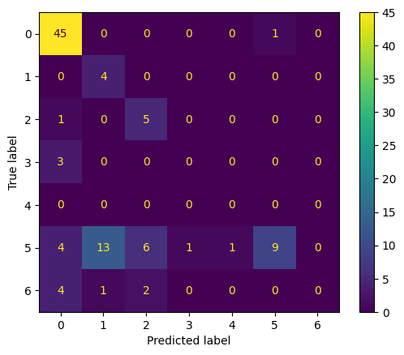

#### Classification Report

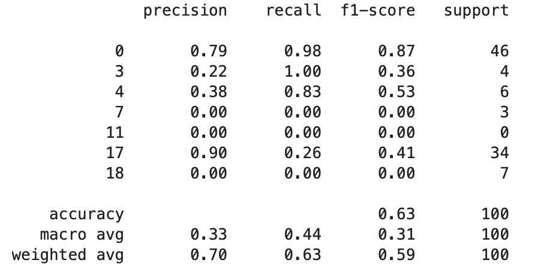

Mean IoU after inference: 0.2303385722104934

### Results

**Overall Performance:**

Accuracy (0.82): This is relatively high, suggesting that the model correctly predicts the label 82% of the time across all classes.

IoU (0.19): The Intersection over Union is a measure of the overlap between the predicted and true labels. An IoU of 0.19 suggests that there is room for improvement, especially in differentiating between classes.

**Confusion Matrix:**

This matrix shows the true labels vs. the predicted labels. Here, most predictions are concentrated along the diagonal, which is good. However, there are misclassifications (off-diagonal elements), i.e., classes 7,11, 18 are not predicted correctly at all suggesting some confusion between classes.

**Classification Report:**

The high recall for class 0 suggests that the model is good at identifying this class but has low precision for other classes like 3 and 4, leading to a lower F1-score.

**Inference:**

Accuracy (0.63): This is lower than the overall accuracy, in addition to the classification report indicating that the model may not generalize as well to unseen data.

Mean IoU after inference (0.23): This is slightly higher than the IoU before inference, which might suggest that the model performs better on average at distinguishing classes during inference compared to training.

**Given the limitations in memory and the use of a toy dataset, these results may not fully represent the model's capabilities on the full dataset. Optimizations and adjustments, including the original dataset, or more balanced datasets and additional feature engineering, might improve performance.**